# R Notebook

### c) Interpret the loadings/correlations of variables at each dimension

$$\begin{bmatrix} \text{ } & \text{dim
1} & \text{dim 2} & \text{ dim 3} & \text{dim 4} &
\text{dim 5} \\ \text{GP} & 0.85687222 & -0.11486900 &
-0.31775776 & 0.01804263 & 0.01727870 \\ \text{GS} &
0.76402405 & -0.07753788 & 0.18749346 & 0.15397436 &
0.27133396 \\ \text{PTS} & 0.90123856 & -0.14650648 &
0.12786493 & 0.15999545 & -0.04516577 \\ \text{2P%} &
0.45749627 & 0.33957340 & -0.46348339 & -0.29803450 &
0.18708070 \\ \text{3%} & 0.09423746 & -0.48561287 &
-0.23973732 & -0.76631509 & 0.10846051 \\ \text{FT%} &
0.61447440 & -0.11809966 & -0.50615410 & -0.19206702 &
0.02201026 \\ \text{OR} & 0.63284824 & 0.68059138 &
0.08009407 & 0.00093709 & 0.01327233 \\ \text{DR} &
0.86356358 & 0.27640035 & 0.09852997 & 0.19639861 &
0.11237273 \\ \text{TR} & 0.83542008 & 0.44362051 &
0.00765144 & 0.18708070 & 0.08792645 \\ \text{AST} &
0.60135464 & -0.56219169 & 0.15200348 & -0.24117852 &
-0.18119268 \\ \text{STL} & 0.72459441 & -0.40032514 &
0.03039414 & -0.07551659 & 0.18928933 \\ \text{TO} &
0.81603210 & -0.31676517 & 0.10189066 & 0.00429364 &
0.09477865 \\ \text{BLK} & 0.34718728 & 0.79605068 &
0.01788220 & 0.07074070 & 0.47709564 \\ \text{BLKA} &
0.58862520 & -0.21749297 & 0.29806622 & 0.11839537 &
0.26446647 \\ \text{FC} & 0.81784142 & -0.03330554 &
-0.14495746 & 0.08700361 & 0.19487947 \\ \text{FD} &
0.83655868 & 0.14245838 & 0.23624674 & 0.13704967 &
0.17646079 \\ \text{Min_total} & 0.95451485 & -0.13153194 &
0.05948906 & 0.09418074 & 0.05140451 \\ \text{Min_2} &
-0.34190991 & 0.04512421 & 0.75170630 & -0.09148074 &
0.29524525 \\ \end{bmatrix}$$

> OSS : **Overall Interpretation**:
> - **Dim.1**: Represents **general player activity and performance**, encompassing both positive and negative contributions across different areas of the game, with a focus on court time, points, and rebounds.
> - **Dim.2**: Reflects a divide between **defensive/physical presence** (blocks, offensive rebounds) and **offensive playmaking and shooting efficiency** (assists, three-point shooting). Players excelling in defensive skills might not be as proficient in offensive finesse.

> This distinction between the two components provides insight into how players perform in different areas, separating general contribution from more specific skills such as defense or playmaking

### d) Plot Correlations Between Variables and Extracted Dimensions

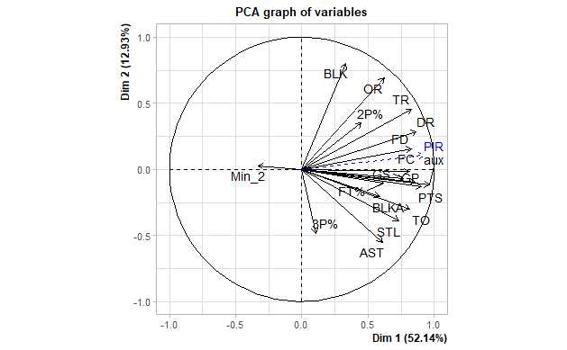

```r
# 1. Generate variable plot for the first two dimensions (Dim.1 and Dim.2)
plot.PCA(pca_result, choix = "var", axes = c(1, 2))
```

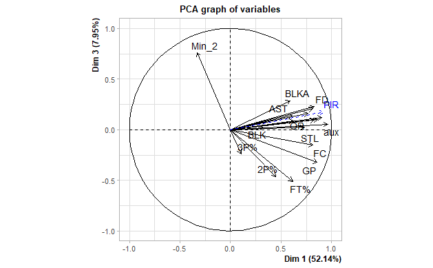

```r
# 2. Generate variable plot for Dimension 1 vs Dimension 3
plot.PCA(pca_result, choix = "var", axes = c(1, 3))
```

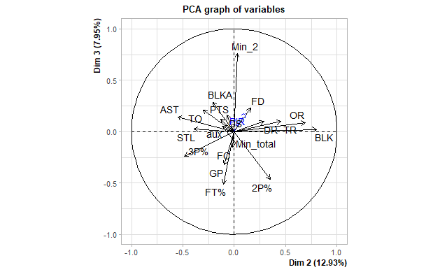

```r
# 3. Generate variable plot for Dimension 2 vs Dimension 3
plot.PCA(pca_result, choix = "var", axes = c(2, 3))
```

### e) Interpret variable plots. How can each dimension be named?

> OSS ### Brief Interpretation of Variable Plots and Naming of Components:
> 1. **Component 1 (Dim.1)**:
>    - **Variable Grouping**: Strong loadings from **Min_total**, **PTS**, **DR**, **GP**, **TR**, and **FD**.
>    - **Theme**: This component reflects **Overall Player Activity and Performance**, encompassing total minutes played, points, rebounds, and games played.
>    - **Suggested Name**: “General Performance and Activity”
> 2. **Component 2 (Dim.2)**:
>    - **Variable Grouping**: High loadings for **BLK**, **OR**, and **TR**, with negative loadings for **AST**, **3P%**, and **STL**.
>    - **Theme**: This component distinguishes **Defensive/Physical Play** (blocks, offensive rebounds) from **Playmaking and Shooting Efficiency** (assists, 3-point percentage).
>    - **Suggested Name**: “Defensive vs. Offensive Play”

> By identifying the key variables and their groupings in each dimension, these names capture the essence of the components based on the most influential factors.